# Mussel Feeding Experiment

Edna Chiang

March 1, 2016

## Notes

Cell size measurements don’t come from the exact ImageJ file as the cell counts. For cell counts, as long as ImageJ recognized each cell with a small dot, I used the file; however, this doesn’t provide a good measurement of cell size. To more accurately measure size I had to change the threshold so that the majority of a cell’s mass was recognized by ImageJ. This caused a lot more noise in the photo, which I tried to decrease by increasing the minimum pixel cluster size counted by the program; however, noise still caused some inaccuracy in the data by viewing some cells larger than they actually were and by counting parts of the background.

```r
library(ggplot2)
library(RColorBrewer)
library(dplyr)
library(lawstat)
library(grid)
library(gridExtra)
## For dplyr notes: http://www.sharpsightlabs.com/dplyr-intro-data-manipulation-with-r/
## For loop notes: http://www.programiz.com/r-programming/for-loop

Size <- read.csv("Cell Size.csv", header=TRUE)
Size <- data.frame(Size)

Size$Sample <- factor(Size$Sample, levels=c("C1T0", "C3T0", "C1T3", "C2T3", "C3T3", "E1T0", "E3T0",
                                            "E1T3", "E2T3", "E3T3"))
Size$Time <- factor(Size$Time, levels=c("Start","End"))
Size$Experiment <- factor(Size$Experiment, levels=c("Control Start", "Control End", "Mussel Start",
                                                    "Mussel End"))

Counts <- read.csv("Cell Counts.csv", header=T)
Counts <- data.frame(Counts)
Counts$Sample <- factor(Counts$Sample, levels=c("C1T0", "C3T0", "C1T3", "C2T3", "C3T3", "E1T0", "E3T0",
                                                "E1T3", "E2T3", "E3T3"))
Counts$Time <- factor(Counts$Time, levels=c("Start","End"))
Counts$Experiment <- factor(Counts$Experiment, levels=c("Control Start", "Control End", "Mussel Start",
                                                        "Mussel End"))
```

## Check Cell Count Data for Normality

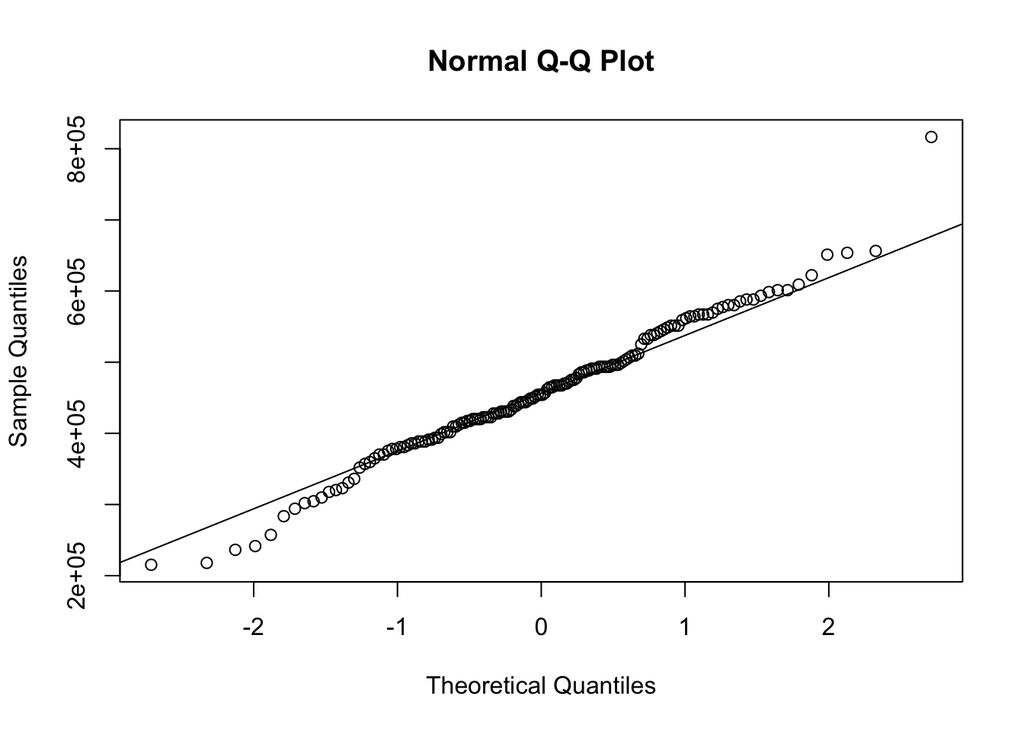

```r
#### Is the COUNT data normal?
qqnorm(Counts$Cells_mL_gen)
qqline(Counts$Cells_mL_gen)
```

```r
ks.test(Counts$Cells_mL_gen, "pnorm", mean=mean(Counts$Cells_mL_gen), sd=sd(Counts$Cells_mL_gen))
```

```
##
##  One-sample Kolmogorov-Smirnov test
##
## data:  Counts$Cells_mL_gen
## D = 0.053517, p-value = 0.7835
## alternative hypothesis: two-sided
```

```r
print("Cell count data is normally distributed", quote=FALSE)
```

```
## [1] Cell count data is normally distributed
```

## Check Cell Size Data for Normality

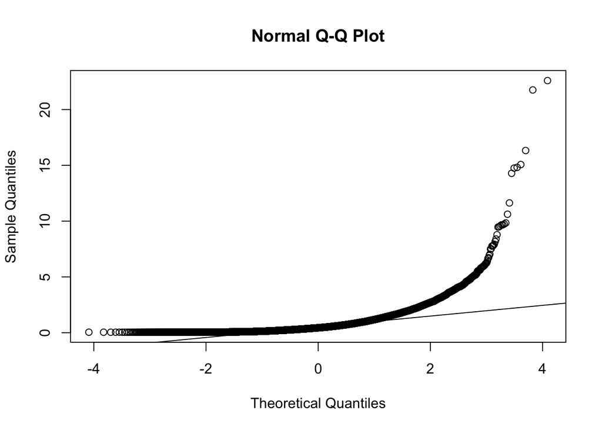

```r
##### Is the SIZE data normal?
qqnorm(Size$Area)
qqline(Size$Area)
```

```r
ks.test(Size$Area, "pnorm", mean=mean(Size$Area), sd=sd(Size$Area))
```

```
##
##  One-sample Kolmogorov-Smirnov test
##
## data:  Size$Area
## D = 0.21439, p-value < 2.2e-16
## alternative hypothesis: two-sided
```

```r
print("Cell size data is not normally distributed", quote=FALSE)
```

```
## [1] Cell size data is not normally distributed
```

```r
Size$AreaLog <- log(Size$Area)
    #Log data to make it (hopefully) normal


print("Log transform data")
```

```
## [1] "Log transform data"
```

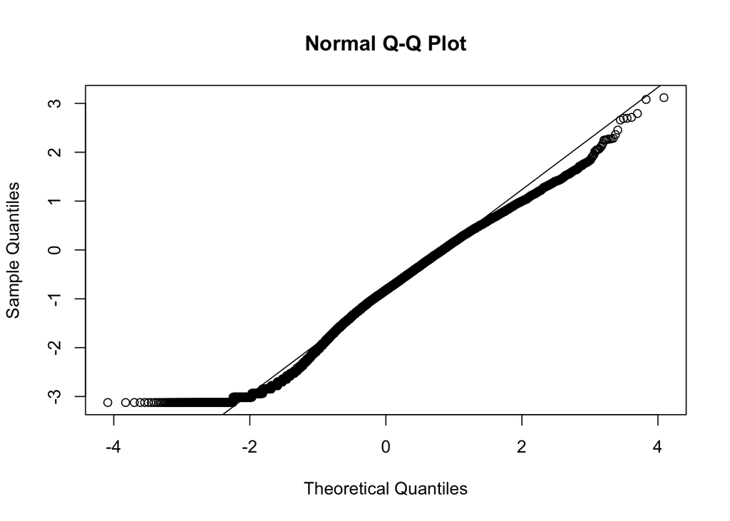

```r
##### Is the SIZE data normal?
qqnorm(Size$AreaLog)
qqline(Size$AreaLog)
```

```r
ks.test(Size$AreaLog, "pnorm", mean=mean(Size$AreaLog), sd=sd(Size$AreaLog))
```

```
##
##  One-sample Kolmogorov-Smirnov test
##
## data:  Size$AreaLog
## D = 0.034557, p-value < 2.2e-16
## alternative hypothesis: two-sided
```

```r
print("Cell size data is not normally distributed", quote = FALSE)
```

```
## [1] Cell size data is not normally distributed
```

## Data Summary

```r
controlstart <- which(Size$Treatment=="Control" & Size$Time=="Start")
musselstart <- which(Size$Treatment=="Mussel" & Size$Time=="Start")
controlend <- which(Size$Treatment=="Control" & Size$Time=="End")
musselend <- which(Size$Treatment=="Mussel" & Size$Time=="End")
```

**Control Start**

```r
print("Cell Count Summary (cells/mL)", quote=F)
```

```
## [1] Cell Count Summary (cells/mL)
```

```r
summary(Counts$Cells_mL_gen[Counts$Experiment=="Control Start"])
```

```
##    Min. 1st Qu.  Median    Mean 3rd Qu.    Max.
##  283600  422000  460800  491900  563200  816500
```

```r
print("Cell Size Summary (um^2)", quote=F)
```

```
## [1] Cell Size Summary (um^2)
```

```r
summary(Size$Area[controlstart])
```

```
##    Min. 1st Qu.  Median    Mean 3rd Qu.    Max.
##  0.0440  0.1690  0.3640  0.5775  0.7470 15.0700
```

```r
print("Number of size counts", quote=F)
```

```
## [1] Number of size counts
```

```r
length(controlstart)
```

```
## [1] 4615
```

**Control End**

```r
print("Cell Count Summary (cells/mL)", quote=F)
```

```
## [1] Cell Count Summary (cells/mL)
```

```r
summary(Counts$Cells_mL_gen[Counts$Experiment=="Control End"])
```

```
##    Min. 1st Qu.  Median    Mean 3rd Qu.    Max.
##  236300  420100  475200  471500  538200  622200
```

```r
print("Cell Size Summary (um^2)", quote=F)
```

```
## [1] Cell Size Summary (um^2)
```

```r
summary(Size$Area[controlend])
```

```
##    Min. 1st Qu.  Median    Mean 3rd Qu.    Max.
##  0.0440  0.2530  0.5290  0.7958  1.0040 21.7600
```

```r
print("Number of size counts", quote=F)
```

```
## [1] Number of size counts
```

```r
length(controlend)
```

```
## [1] 7553
```

**Mussel Start**

```r
print("Cell Count Summary (cells/mL)", quote=F)
```

```
## [1] Cell Count Summary (cells/mL)
```

```r
summary(Counts$Cells_mL_gen[Counts$Experiment=="Mussel Start"])
```

```
##    Min. 1st Qu.  Median    Mean 3rd Qu.    Max.
##  217900  444400  493600  489700  550700  656400
```

```r
print("Cell Size Summary (um^2)", quote=F)
```

```
## [1] Cell Size Summary (um^2)
```

```r
summary(Size$Area[musselstart])
```

```
##    Min. 1st Qu.  Median    Mean 3rd Qu.    Max.
##  0.0440  0.2040  0.4090  0.6503  0.8530  8.1640
```

```r
print("Number of size counts", quote=F)
```

```
## [1] Number of size counts
```

```r
length(musselstart)
```

```
## [1] 4629
```

**Mussel End**

```r
print("Cell Count Summary (cells/mL)", quote=F)
```

```
## [1] Cell Count Summary (cells/mL)
```

```r
summary(Counts$Cells_mL_gen[Counts$Experiment=="Mussel End"])
```

```
##    Min. 1st Qu.  Median    Mean 3rd Qu.    Max.
##  215300  370200  412200  403600  454200  551400
```

```r
print("Cell Size Summary (um^2)", quote=F)
```

```
## [1] Cell Size Summary (um^2)
```

```r
summary(Size$Area[musselend])
```

```
##    Min. 1st Qu.  Median    Mean 3rd Qu.    Max.
##  0.0440  0.2040  0.4180  0.6105  0.7640 22.6000
```

```r
print("Number of size counts", quote=F)
```

```
## [1] Number of size counts
```

```r
length(musselend)
```

```
## [1] 6217
```

There are 3 End samples and 2 Start samples, so there are substaintly more End counts compared to Start counts.

## Cell Count Analyses

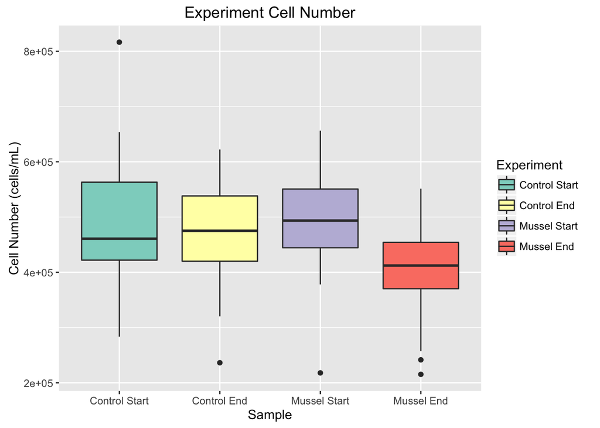

```r
#### Cell Count Boxplot
ggplot(data=Counts, aes(x=Experiment, y=Cells_mL_gen, fill=Experiment)) + geom_boxplot() +
  scale_fill_brewer(palette="Set3") + ylab("Cell Number (cells/mL)") + ggtitle("Experiment Cell Number") +
  xlab("Sample")
```

```r
levene.test(y=Counts$Cells_mL_gen, group=Counts$Experiment)
```

```
##
##  modified robust Brown-Forsythe Levene-type test based on the
##  absolute deviations from the median
##
## data:  Counts$Cells_mL_gen
## Test Statistic = 0.92112, p-value = 0.4323
```

```r
print("Experiment cell count variances are not significantly different")
```

```
## [1] "Experiment cell count variances are not significantly different"
```

```r
anovacount <- aov(Cells_mL_gen~Experiment, data=Counts)
summary(anovacount)
```

```
##              Df    Sum Sq   Mean Sq F value   Pr(>F)
## Experiment    3 2.057e+11 6.857e+10   8.814 2.08e-05 ***
## Residuals   146 1.136e+12 7.779e+09
## ---
## Signif. codes:  0 '***' 0.001 '**' 0.01 '*' 0.05 '.' 0.1 ' ' 1
```

```r
print("Experiment cell count means are significantly different")
```

```
## [1] "Experiment cell count means are significantly different"
```

```r
cs <- which(Counts$Experiment=="Control Start")
ce <- which(Counts$Experiment=="Control End")
ms <- which(Counts$Experiment=="Mussel Start")
me <- which(Counts$Experiment=="Mussel End")

t.test(x=Counts$Cells_mL_gen[cs], y=Counts$Cells_mL_gen[ce])
```

```
##
##  Welch Two Sample t-test
##
## data:  Counts$Cells_mL_gen[cs] and Counts$Cells_mL_gen[ce]
## t = 0.86624, df = 51.697, p-value = 0.3904
## alternative hypothesis: true difference in means is not equal to 0
## 95 percent confidence interval:
##  -26928.59  67828.03
## sample estimates:
## mean of x mean of y
##  491931.0  471481.2
```

```r
print("There is no significant change in cell number between Control Start & End")
```

```
## [1] "There is no significant change in cell number between Control Start & End"
```

```r
t.test(x=Counts$Cells_mL_gen[cs], y=Counts$Cells_mL_gen[ms])
```

```
##
##  Welch Two Sample t-test
##
## data:  Counts$Cells_mL_gen[cs] and Counts$Cells_mL_gen[ms]
## t = 0.090023, df = 54.814, p-value = 0.9286
## alternative hypothesis: true difference in means is not equal to 0
## 95 percent confidence interval:
##  -48383.15  52934.02
## sample estimates:
## mean of x mean of y
##  491931.0  489655.5
```

```r
print("There is no significant difference in cell number between Control & Mussel Start")
```

```
## [1] "There is no significant difference in cell number between Control & Mussel Start"
```

```r
t.test(x=Counts$Cells_mL_gen[ms], y=Counts$Cells_mL_gen[me], alternative="greater")
```

```
##
##  Welch Two Sample t-test
##
## data:  Counts$Cells_mL_gen[ms] and Counts$Cells_mL_gen[me]
## t = 4.4456, df = 57.879, p-value = 2.013e-05
## alternative hypothesis: true difference in means is greater than 0
## 95 percent confidence interval:
##  53680.46      Inf
## sample estimates:
## mean of x mean of y
##  489655.5  403626.7
```

```r
print("Cell number in Mussel Start is significantly larger than that in Mussel End")
```

```
## [1] "Cell number in Mussel Start is significantly larger than that in Mussel End"
```

## Cell Size

1um = 15 pixels  
1um^2 = 225 pixels^2

```r
#### This removes the extremely large cell size measures
big <- which(Size$Area>5)  ## Gives indices of TRUE
Size$AreaTrans <- Size$Area
Size$AreaTrans[big] <- 5

#### Cell Size Summary
print("Cell Size Summary (um^2)")
```

```
## [1] "Cell Size Summary (um^2)"
```

```r
summary(Size$Area)
```

```
##    Min. 1st Qu.  Median    Mean 3rd Qu.    Max.
##  0.0440  0.2090  0.4400  0.6727  0.8580 22.6000
```

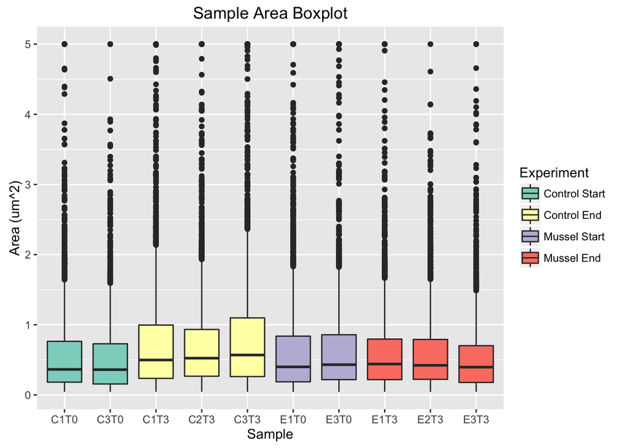

```r
#### Cell Size Boxplot
ggplot(data=Size, aes(x=Sample, y=AreaTrans, fill=Experiment)) + geom_boxplot() +
  scale_fill_brewer(palette="Set3") + ylab("Area (um^2)") + ggtitle("Sample Area Boxplot")
```

```r
print("Y-axis max is 5+ um^2", quotes="F")
```

```
## [1] "Y-axis max is 5+ um^2"
```

## Sample Cell Size Histogram

Scaled histogram: cell size counts were divided by mean sample count per sample.

```r
sampcolors <- c(C1T0="#a6cee3", C3T0="#1f78b4", C1T3="#c7e9c0", C2T3="#74c476", C3T3="#006d2c",
                E1T0="#fa9fb5", E3T0="#cb181d", E1T3="#fcae91", E2T3="#fb6a4a", E3T3="#67000d")

#### Create median size value for each sample
medsamp <- c(median(Size$Area[Size$Sample=="C1T0"]), median(Size$Area[Size$Sample=="C3T0"]),
             median(Size$Area[Size$Sample=="C1T3"]), median(Size$Area[Size$Sample=="C2T3"]),
             median(Size$Area[Size$Sample=="C3T3"]), median(Size$Area[Size$Sample=="E1T0"]),
             median(Size$Area[Size$Sample=="E3T0"]), median(Size$Area[Size$Sample=="E1T3"]),
             median(Size$Area[Size$Sample=="E2T3"]), median(Size$Area[Size$Sample=="E3T3"]))
medsamp <- data.frame(medsamp)
medsamp$Median <- medsamp$medsamp
medsamp$medsamp <- NULL
medsamp$Sample <- c("C1T0", "C3T0", "C1T3", "C2T3", "C3T3", "E1T0", "E3T0", "E1T3", "E2T3", "E3T3")
medsamp$Sample <- factor(medsamp$Sample, levels=c("C1T0", "C3T0", "C1T3", "C2T3", "C3T3", "E1T0",
                                                  "E3T0", "E1T3", "E2T3", "E3T3"))

# #### Histogram of data (skewed)
# print("Black line represents median of each sample", quote=F)
# ggplot(data=Size, aes(x=AreaTrans, fill=Sample)) + geom_histogram() + facet_grid(Sample~.) +
#   scale_fill_brewer(palette="Paired") + xlab("Area (pixels^2)") + ggtitle("Sample Cell Size") +
#   geom_vline(aes(xintercept=Median), medsamp) + scale_fill_manual(values = sampcolors)
#
#
# #### Histogram with log scale
# print("Black line represents median of each sample", quote=F)
# ggplot(data=Size, aes(x=Area, fill=Sample)) + geom_histogram() + facet_grid(Sample~.) +
#   scale_x_log10() + scale_fill_brewer(palette="Paired") + xlab("Area (pixels^2)") +
#   ggtitle("Sample Cell Size (Log Scale)") + geom_vline(aes(xintercept=Median), medsamp) +
#   scale_fill_manual(values = sampcolors)


################################### Scaled Sample Cell Size Histogram  ###################
###Cell size counts were divided by mean sample count per sample.

sampcolors <- c(C1T0="#a6cee3", C3T0="#1f78b4", C1T3="#c7e9c0", C2T3="#74c476", C3T3="#006d2c",
                E1T0="#fa9fb5", E3T0="#cb181d", E1T3="#fcae91", E2T3="#fb6a4a", E3T3="#67000d")

#### Scale cell size by average sample counts
## Create dataframe of average sample counts
avgsamp <- c(mean(Counts$Cells[Counts$Sample=="C1T0"]), mean(Counts$Cells[Counts$Sample=="C3T0"]),
             mean(Counts$Cells[Counts$Sample=="C1T3"]), mean(Counts$Cells[Counts$Sample=="C2T3"]),
             mean(Counts$Cells[Counts$Sample=="C3T3"]), mean(Counts$Cells[Counts$Sample=="E1T0"]),
             mean(Counts$Cells[Counts$Sample=="E3T0"]), mean(Counts$Cells[Counts$Sample=="E1T3"]),
             mean(Counts$Cells[Counts$Sample=="E2T3"]), mean(Counts$Cells[Counts$Sample=="E3T3"]))
avgsamp <- data.frame(avgsamp)
avgsamp$Mean <- avgsamp$avgsamp
avgsamp$avgsamp <- NULL
avgsamp$Sample <- c("C1T0", "C3T0", "C1T3", "C2T3", "C3T3", "E1T0", "E3T0", "E1T3", "E2T3", "E3T3")
avgsamp$Sample <- factor(medsamp$Sample, levels=c("C1T0", "C3T0", "C1T3", "C2T3", "C3T3", "E1T0",
                                                  "E3T0", "E1T3", "E2T3", "E3T3"))

## Divide cell area (<600 pixels^2) by average cell count
x <- which(Size$Sample=="C1T0")
Size$AreaScale <- NA
Size$AreaScale[1:max(x)] <- Size$AreaTrans[1:max(x)]/avgsamp[1,1]
y <- which(Size$Sample=="C3T0")
Size$AreaScale[max(x+1):max(y)] <- Size$AreaTrans[max(x+1):max(y)]/avgsamp[2,1]
x <- which(Size$Sample=="E1T0")
Size$AreaScale[max(y+1):max(x)] <- Size$AreaTrans[max(y+1):max(x)]/avgsamp[6,1]
y <- which(Size$Sample=="E3T0")
Size$AreaScale[max(x+1):max(y)] <- Size$AreaTrans[max(x+1):max(y)]/avgsamp[7,1]
x <- which(Size$Sample=="C1T3")
Size$AreaScale[max(y+1):max(x)] <- Size$AreaTrans[max(y+1):max(x)]/avgsamp[3,1]
y <- which(Size$Sample=="C2T3")
Size$AreaScale[max(x+1):max(y)] <- Size$AreaTrans[max(x+1):max(y)]/avgsamp[4,1]
x <- which(Size$Sample=="C3T3")
Size$AreaScale[max(y+1):max(x)] <- Size$AreaTrans[max(y+1):max(x)]/avgsamp[5,1]
y <- which(Size$Sample=="E1T3")
Size$AreaScale[max(x+1):max(y)] <- Size$AreaTrans[max(x+1):max(y)]/avgsamp[8,1]
x <- which(Size$Sample=="E2T3")
Size$AreaScale[max(y+1):max(x)] <- Size$AreaTrans[max(y+1):max(x)]/avgsamp[9,1]
y <- which(Size$Sample=="E3T3")
Size$AreaScale[max(x+1):max(y)] <- Size$AreaTrans[max(x+1):max(y)]/avgsamp[10,1]

#### Create median value for scaled cell size
medscale <- c(median(Size$AreaScale[Size$Sample=="C1T0"]), median(Size$AreaScale[Size$Sample=="C3T0"]),
             median(Size$AreaScale[Size$Sample=="C1T3"]), median(Size$AreaScale[Size$Sample=="C2T3"]),
             median(Size$AreaScale[Size$Sample=="C3T3"]), median(Size$AreaScale[Size$Sample=="E1T0"]),
             median(Size$AreaScale[Size$Sample=="E3T0"]), median(Size$AreaScale[Size$Sample=="E1T3"]),
             median(Size$AreaScale[Size$Sample=="E2T3"]), median(Size$AreaScale[Size$Sample=="E3T3"]))
medscale <- data.frame(medscale)
medscale$Median <- medscale$medscale
medscale$medscale <- NULL
medscale$Sample <- c("C1T0", "C3T0", "C1T3", "C2T3", "C3T3", "E1T0", "E3T0", "E1T3", "E2T3", "E3T3")
medscale$Sample <- factor(medscale$Sample, levels=c("C1T0", "C3T0", "C1T3", "C2T3", "C3T3", "E1T0",
                                                  "E3T0", "E1T3", "E2T3", "E3T3"))

# #### Histogram of scaled cell size (skewed)
# ggplot(data=Size, aes(x=AreaScale, fill=Sample)) + geom_histogram() + facet_grid(Sample~.) +
#   scale_fill_brewer(palette="Paired") + xlab("Scaled Area") + ggtitle("Scaled Sample Cell Size") +
#   geom_vline(aes(xintercept=Median), medscale) + scale_fill_manual(values = sampcolors)


#### Histogram of scaled data on log scale ####

## Divide cell area (original data) by average cell count
x <- which(Size$Sample=="C1T0")
Size$AreaOrigScale <- NA
Size$AreaOrigScale[1:max(x)] <- Size$Area[1:max(x)]/avgsamp[1,1]
y <- which(Size$Sample=="C3T0")
Size$AreaOrigScale[max(x+1):max(y)] <- Size$Area[max(x+1):max(y)]/avgsamp[2,1]
x <- which(Size$Sample=="E1T0")
Size$AreaOrigScale[max(y+1):max(x)] <- Size$Area[max(y+1):max(x)]/avgsamp[6,1]
y <- which(Size$Sample=="E3T0")
Size$AreaOrigScale[max(x+1):max(y)] <- Size$Area[max(x+1):max(y)]/avgsamp[7,1]
x <- which(Size$Sample=="C1T3")
Size$AreaOrigScale[max(y+1):max(x)] <- Size$Area[max(y+1):max(x)]/avgsamp[3,1]
y <- which(Size$Sample=="C2T3")
Size$AreaOrigScale[max(x+1):max(y)] <- Size$Area[max(x+1):max(y)]/avgsamp[4,1]
x <- which(Size$Sample=="C3T3")
Size$AreaOrigScale[max(y+1):max(x)] <- Size$Area[max(y+1):max(x)]/avgsamp[5,1]
y <- which(Size$Sample=="E1T3")
Size$AreaOrigScale[max(x+1):max(y)] <- Size$Area[max(x+1):max(y)]/avgsamp[8,1]
x <- which(Size$Sample=="E2T3")
Size$AreaOrigScale[max(y+1):max(x)] <- Size$Area[max(y+1):max(x)]/avgsamp[9,1]
y <- which(Size$Sample=="E3T3")
Size$AreaOrigScale[max(x+1):max(y)] <- Size$Area[max(x+1):max(y)]/avgsamp[10,1]

#### Create median value for scaled cell size
medorigscale <- c(median(Size$AreaScale[Size$Sample=="C1T0"]),
                  median(Size$AreaScale[Size$Sample=="C3T0"]),
                  median(Size$AreaScale[Size$Sample=="C1T3"]),
                  median(Size$AreaScale[Size$Sample=="C2T3"]),
                  median(Size$AreaScale[Size$Sample=="C3T3"]),
                  median(Size$AreaScale[Size$Sample=="E1T0"]),
                  median(Size$AreaScale[Size$Sample=="E3T0"]),
                  median(Size$AreaScale[Size$Sample=="E1T3"]),
                  median(Size$AreaScale[Size$Sample=="E2T3"]),
                  median(Size$AreaScale[Size$Sample=="E3T3"]))
medorigscale <- data.frame(medorigscale)
medorigscale$Median <- medorigscale$medorigscale
medorigscale$medscale <- NULL
medorigscale$Sample <- c("C1T0", "C3T0", "C1T3", "C2T3", "C3T3", "E1T0", "E3T0", "E1T3", "E2T3", "E3T3")
medorigscale$Sample <- factor(medorigscale$Sample, levels=c("C1T0", "C3T0", "C1T3", "C2T3", "C3T3",
                                                            "E1T0", "E3T0", "E1T3", "E2T3", "E3T3"))

# #### Histogram of scaled cell size with log-scaled axis
# ggplot(data=Size, aes(x=AreaOrigScale, fill=Sample)) + geom_histogram() + facet_grid(Sample~.) +
#   scale_fill_brewer(palette="Paired") + xlab("Scaled Area") + ggtitle("Scaled Sample Cell Size") +
#   geom_vline(aes(xintercept=Median), medorigscale) + scale_fill_manual(values = sampcolors) +
#   scale_x_log10()





###### http://www.cookbook-r.com/Graphs/Multiple_graphs_on_one_page_(ggplot2)/
multiplot <- function(..., plotlist=NULL, file, cols=1, layout=NULL) {
  library(grid)

  # Make a list from the ... arguments and plotlist
  plots <- c(list(...), plotlist)

  numPlots = length(plots)

  # If layout is NULL, then use 'cols' to determine layout
  if (is.null(layout)) {
    # Make the panel
    # ncol: Number of columns of plots
    # nrow: Number of rows needed, calculated from # of cols
    layout <- matrix(seq(1, cols * ceiling(numPlots/cols)),
                    ncol = cols, nrow = ceiling(numPlots/cols))
  }

 if (numPlots==1) {
    print(plots[[1]])

  } else {
    # Set up the page
    grid.newpage()
    pushViewport(viewport(layout = grid.layout(nrow(layout), ncol(layout))))

    # Make each plot, in the correct location
    for (i in 1:numPlots) {
      # Get the i,j matrix positions of the regions that contain this subplot
      matchidx <- as.data.frame(which(layout == i, arr.ind = TRUE))

      print(plots[[i]], vp = viewport(layout.pos.row = matchidx$row,
                                      layout.pos.col = matchidx$col))
    }
  }
}

######
skeworig <-ggplot(data=Size, aes(x=AreaTrans, fill=Sample)) + geom_histogram() + facet_grid(Sample~.) +
   scale_fill_brewer(palette="Paired") + xlab("Area (pixels^2)") + ggtitle("Sample Cell Size") +
   geom_vline(aes(xintercept=Median), medsamp) + scale_fill_manual(values = sampcolors)
```

```
## which will replace the existing scale.
```

```r
skewscale <- ggplot(data=Size, aes(x=AreaScale, fill=Sample)) + geom_histogram() +
   facet_grid(Sample~.) + scale_fill_brewer(palette="Paired") + xlab("Scaled Area") +
   ggtitle("Scaled Sample Cell Size") + geom_vline(aes(xintercept=Median), medscale) +
   scale_fill_manual(values = sampcolors)
```

```
## which will replace the existing scale.
```

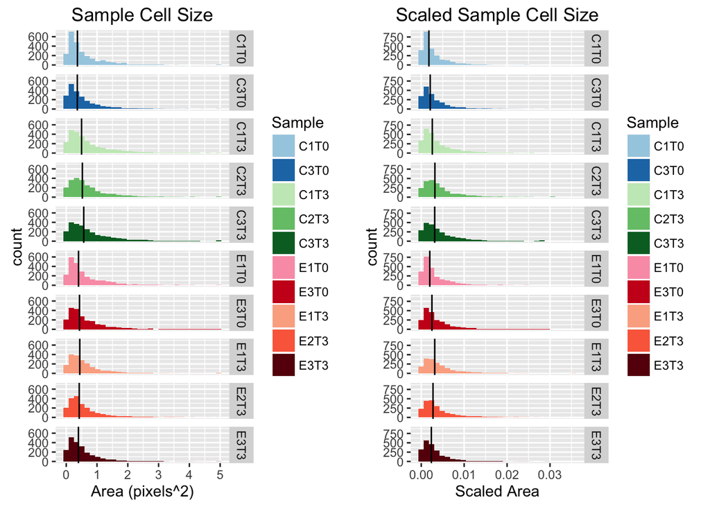

```r
#grid.arrange(skeworig, skewscale)
multiplot(skeworig, skewscale, cols=2)
```

```r
#http://www.cookbook-r.com/Graphs/Multiple_graphs_on_one_page_(ggplot2)/

skewlogorig <- ggplot(data=Size, aes(x=Area, fill=Sample)) + geom_histogram() + facet_grid(Sample~.) +
  scale_x_log10() + scale_fill_brewer(palette="Paired") + xlab("Area (log scale)") +
  ggtitle("Sample Cell Size (Log Scale)") + geom_vline(aes(xintercept=Median), medsamp) +
  scale_fill_manual(values = sampcolors)
```

```
## which will replace the existing scale.
```

```r
skewlogscale <- ggplot(data=Size, aes(x=AreaOrigScale, fill=Sample)) + geom_histogram() +
  facet_grid(Sample~.) + scale_fill_brewer(palette="Paired") + xlab("Scaled Area (log scale)") +
  ggtitle("Scaled Sample Cell Size (Log Scale)") + geom_vline(aes(xintercept=Median), medorigscale) +
  scale_fill_manual(values = sampcolors) + scale_x_log10()
```

```
## which will replace the existing scale.
```

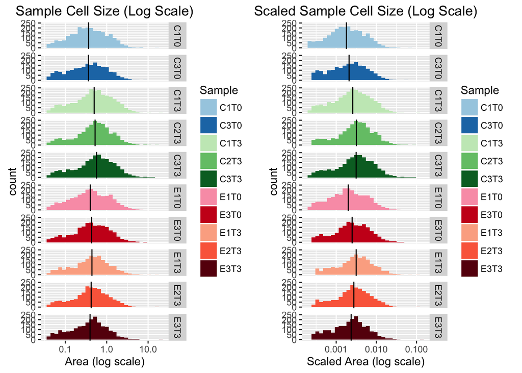

```r
multiplot(skewlogorig, skewlogscale, cols=2)
```

## Experiment Histogram

Experiment cell size counts were scaled by number of replicates.  
Each histogram bin was divided by number of replicates. * Start experiments divided by 2 * End experiments divided by 3

```r
#### Create median value for each experiment
medtt <- c(median(Size$Area[controlstart]), median(Size$Area[controlend]),
           median(Size$Area[musselstart]), median(Size$Area[musselend]))
medtt <- data.frame(medtt)
medtt$Median <- medtt$medtt
medtt$medtt <- NULL
medtt$Treatment <- c("Control", "Control", "Mussel", "Mussel")
medtt$Time <- c("Start", "End", "Start", "End")
medtt$Treatment <- factor(medtt$Treatment, levels=c("Control", "Mussel"))
medtt$Time <- factor(medtt$Time, levels=c("Start", "End"))

# #### Histogram of unscaled data (skewed)
# print("Black line represents median of each treatment", quote=F)
# ggplot(data=Size, aes(x=AreaTrans, fill=Treatment)) + geom_histogram() +
#   facet_grid(Treatment~Time) + ggtitle("Treatment Cell Size") +
#   geom_vline(aes(xintercept=Median), medtt)
#
# #### Histogram of unscaled data with log scale
# print("Black line represents median of each treatment", quote=F)
# ggplot(data=Size, aes(x=Area, fill=Treatment)) + geom_histogram() + facet_grid(Treatment~Time) +
#   scale_x_log10() + ggtitle("Treatment Cell Size") + geom_vline(aes(xintercept=Median), medtt)







#### Scaled Experiment Histogram

#### Histogram of scaled data (skewed)
scalmedtt <- c(median(Size$AreaScale[controlstart]), median(Size$AreaScale[controlend]),
           median(Size$AreaScale[musselstart]), median(Size$AreaScale[musselend]))
scalmedtt <- data.frame(scalmedtt)
scalmedtt$Median <- scalmedtt$scalmedtt
scalmedtt$medtt <- NULL
scalmedtt$Treatment <- c("Control", "Control", "Mussel", "Mussel")
scalmedtt$Time <- c("Start", "End", "Start", "End")
scalmedtt$Treatment <- factor(scalmedtt$Treatment, levels=c("Control", "Mussel"))
scalmedtt$Time <- factor(scalmedtt$Time, levels=c("Start", "End"))


#### Subset out each experiment
cstrim <- Size %>%                          # Select dataframe Size, THEN
  filter(Experiment=="Control Start") %>%   # Filter out Control Start samples, THEN
  arrange(AreaScale)                        # Arrange samples by AreScale
cetrim <- Size %>%
  filter(Experiment=="Control End") %>%
  arrange(AreaScale)
mstrim <- Size %>%
  filter(Experiment=="Mussel Start") %>%
  arrange(AreaScale)
metrim <- Size %>%
  filter(Experiment=="Mussel End") %>%
  arrange(AreaScale)

#### Scale experiment subsets (start = div by 2, end = div by 3)
## First plot the graph that you want to scale & print out the bin number onto the image using the code:
      # + stat_bin(bins=30, aes(y=..count.., label=..count..), geom="text", vjust=-.5)

          # tiff(file="test.tiff", width= 21, height=6.5, units = "in", res = 175)
          # ggplot(data=Size, aes(x=AreaScale, fill=Treatment)) + geom_histogram() + facet_grid(Treatment~Time) + ggtitle("Treatment Cell Size") + geom_vline(aes(xintercept=Median), scalmedtt) + stat_bin( aes(y=..count.., label=..count..), geom="text", vjust=-.5)
          #dev.off()
## Then hand-copy down bin size (save image in a large size to see numbers)
## Divide bin size by replicates (start = 2, end = 3), rounding
## The calculated number will then be subtracted from the experiment subsets, starting from largest area
      # and going to smallest area -> this scales the # of counts in each bin

### Scale Control Start
# Largest bin is 29, so remove 15
x <- nrow(cstrim)
#nrow(cstrim) = 4615
cstrim <- cstrim[-(x-15+1):-x,] # Remove 15 rows
#nrow(cstrim) = 4600
x <- x-29

# Next bin is 6, so remove 3
cstrim <- cstrim[-(x-3+1):-x,] # Remove 3 rows
#nrow(cstrim) = 4597
x <- x-6

# Next bin is 8, so remove 4
cstrim <- cstrim[-(x-4+1):-x,] # Remove 4 rows
#nrow(cstrim) = 4593
x <- x-8

# Next bin is 3, so remove 2
cstrim <- cstrim[-(x-2+1):-x,] # Remove 2 rows
#nrow(cstrim) = 4591
x <- x-3

# Next bin is 57, so remove 29
cstrim <- cstrim[-(x-29+1):-x,] # Remove 29 rows
#nrow(cstrim) = 4562
x <- x-57

# Next bin is 12, so remove 6
cstrim <- cstrim[-(x-6+1):-x,] # Remove 6 rows
#nrow(cstrim) = 4556
x <- x-12

# Next bin is 29, so remove 15
cstrim <- cstrim[-(x-15+1):-x,] # Remove 15 rows
#nrow(cstrim) = 4541
x <- x-29

# Next bin is 18, so remove 9
cstrim <- cstrim[-(x-9+1):-x,] # Remove 15 rows
#nrow(cstrim) = 4532
x <- x-18

# Next bin is 25, so remove 13
cstrim <- cstrim[-(x-13+1):-x,] # Remove 13 rows
#nrow(cstrim) = 4519
x <- x-25

# Next bin is 50, so remove 25
cstrim <- cstrim[-(x-25+1):-x,] # Remove 25 rows
#nrow(cstrim) = 4494
x <- x-50

# Next bin is 50, so remove 25
cstrim <- cstrim[-(x-25+1):-x,] # Remove 25 rows
#nrow(cstrim) = 4469
x <- x-50

# Next bin is 50, so remove 25
cstrim <- cstrim[-(x-25+1):-x,] # Remove 25 rows
#nrow(cstrim) = 4444
x <- x-50

# Next bin is 78, so remove 39
cstrim <- cstrim[-(x-39+1):-x,] # Remove 39 rows
#nrow(cstrim) = 4405
x <- x-78

# Next bin is 70, so remove 35
cstrim <- cstrim[-(x-35+1):-x,] # Remove 35 rows
#nrow(cstrim) = 4370
x <- x-70

# Next bin is 100, so remove 50
cstrim <- cstrim[-(x-50+1):-x,] # Remove 50 rows
#nrow(cstrim) = 4320
x <- x-100

# Next bin is 130, so remove 65
cstrim <- cstrim[-(x-65+1):-x,] # Remove 65 rows
#nrow(cstrim) = 4255
x <- x-130

# Next bin is 137, so remove 69
cstrim <- cstrim[-(x-69+1):-x,] # Remove 69 rows
#nrow(cstrim) = 4118
x <- x-137

# Next bin is 166, so remove 83
cstrim <- cstrim[-(x-83+1):-x,] # Remove 83 rows
#nrow(cstrim) = 4035
x <- x-166

# Next bin is 207, so remove 104
cstrim <- cstrim[-(x-104+1):-x,] # Remove 104 rows
#nrow(cstrim) = 3931
x <- x-207

# Next bin is 274, so remove 137
cstrim <- cstrim[-(x-137+1):-x,] # Remove 137 rows
#nrow(cstrim) = 3794
x <- x-274

# Next bin is 351, so remove 176
cstrim <- cstrim[-(x-176+1):-x,] # Remove 176 rows
#nrow(cstrim) = 3618
x <- x-351

# Next bin is 484, so remove 242
cstrim <- cstrim[-(x-242+1):-x,] # Remove 242 rows
#nrow(cstrim) = 3376
x <- x-484

# Next bin is 646, so remove 323
cstrim <- cstrim[-(x-323+1):-x,] # Remove 323 rows
#nrow(cstrim) = 4405
x <- x-646

# Next bin is 869, so remove 435
cstrim <- cstrim[-(x-435+1):-x,] # Remove 435 rows
#nrow(cstrim) = 4405
x <- x-869

# Next bin is 766, so remove 383
cstrim <- cstrim[-(x-383+1):-x,] # Remove 383 rows
#nrow(cstrim) = 2235
x <- x-766
```

```r
### Start with Control End
# Largest bin is 75, so remove 50
x <- nrow(cetrim)
#nrow(cetrim) = 7553
cetrim <- cetrim[-(x-50+1):-x,] # Remove 50 rows
#nrow(cetrim) = 7503
x <- x-75

# Next bin is 6, so remove 4
cetrim <- cetrim[-(x-4+1):-x,] # Remove 4 rows
#nrow(cetrim) = 7499
x <- x-6

# Next bin is 124, so remove 83
cetrim <- cetrim[-(x-83+1):-x,] # Remove 83 rows
#nrow(cetrim) = 7416
x <- x-124

# Next bin is 27, so remove 18
cetrim <- cetrim[-(x-18+1):-x,] # Remove 18 rows
#nrow(cetrim) = 7398
x <- x-27

# Next bin is 143, so remove 95
cetrim <- cetrim[-(x-95+1):-x,] # Remove 95 rows
#nrow(cetrim) = 7303
x <- x-143

# Next bin is 52, so remove 35
cetrim <- cetrim[-(x-35+1):-x,] # Remove 35 rows
#nrow(cetrim) = 7268
x <- x-52

# Next bin is 63, so remove 42
cetrim <- cetrim[-(x-42+1):-x,] # Remove 42 rows
#nrow(cetrim) = 7226
x <- x-63

# Next bin is 69, so remove 46
cetrim <- cetrim[-(x-46+1):-x,] # Remove 46 rows
#nrow(cetrim) = 7180
x <- x-69

# Next bin is 81, so remove 54
cetrim <- cetrim[-(x-54+1):-x,] # Remove 54 rows
#nrow(cetrim) = 7126
x <- x-81

# Next bin is 89, so remove 59
cetrim <- cetrim[-(x-59+1):-x,] # Remove 59 rows
#nrow(cetrim) = 7067
x <- x-89

# Next bin is 105, so remove 70
cetrim <- cetrim[-(x-70+1):-x,] # Remove 70 rows
#nrow(cetrim) = 6997
x <- x-105

# Next bin is 134, so remove 89
cetrim <- cetrim[-(x-89+1):-x,] # Remove 89 rows
#nrow(cetrim) = 6908
x <- x-134

# Next bin is 131, so remove 87
cetrim <- cetrim[-(x-87+1):-x,] # Remove 87 rows
#nrow(cetrim) = 6821
x <- x-131

# Next bin is 157, so remove 105
cetrim <- cetrim[-(x-105+1):-x,] # Remove 105 rows
#nrow(cetrim) = 6716
x <- x-157

# Next bin is 170, so remove 113
cetrim <- cetrim[-(x-113+1):-x,] # Remove 113 rows
#nrow(cetrim) = 6603
x <- x-170

# Next bin is 194, so remove 129
cetrim <- cetrim[-(x-129+1):-x,] # Remove 129 rows
#nrow(cetrim) = 6474
x <- x-194

# Next bin is 264, so remove 176
cetrim <- cetrim[-(x-176+1):-x,] # Remove 176 rows
#nrow(cetrim) = 6298
x <- x-264

# Next bin is 304, so remove 203
cetrim <- cetrim[-(x-203+1):-x,] # Remove 203 rows
#nrow(cetrim) = 6095
x <- x-304

# Next bin is 383, so remove 255
cetrim <- cetrim[-(x-255+1):-x,] # Remove 255 rows
#nrow(cetrim) = 5840
x <- x-383

# Next bin is 428, so remove 285
cetrim <- cetrim[-(x-285+1):-x,] # Remove 285 rows
#nrow(cetrim) = 5555
x <- x-428

# Next bin is 595, so remove 397
cetrim <- cetrim[-(x-397+1):-x,] # Remove 397 rows
#nrow(cetrim) = 5158
x <- x-595

# Next bin is 670, so remove 447
cetrim <- cetrim[-(x-447+1):-x,] # Remove 447 rows
#nrow(cetrim) = 4711
x <- x-670

# Next bin is 813, so remove 542
cetrim <- cetrim[-(x-542+1):-x,] # Remove 542 rows
#nrow(cetrim) = 4440
x <- x-813

# Next bin is 770, so remove 513
cetrim <- cetrim[-(x-513+1):-x,] # Remove 513 rows
#nrow(cetrim) = 5573
x <- x-770

# Next bin is 811, so remove 541
cetrim <- cetrim[-(x-541+1):-x,] # Remove 541 rows
#nrow(cetrim) = 3386
x <- x-811

# Next bin is 895, so remove 597
cetrim <- cetrim[-(x-597+1):-x,] # Remove 326 rows
#nrow(mstrim) = 2310
x <- x-895


### Start with Mussel Start
# Largest bin is 57, so remove 29
x <- nrow(mstrim)
#nrow(mstrim) = 4629
mstrim <- mstrim[-(x-29+1):-x,] # Remove 29 rows
#nrow(mstrim) = 4600
x <- x-57

# Next bin is 4, so remove 2
mstrim <- mstrim[-(x-2+1):-x,] # Remove 2 rows
#nrow(mstrim) = 4598
x <- x-4

# Next bin is 1, so remove 0
#mstrim <- mstrim[-(x-2+1):-x,] # Remove 0 rows
#nrow(mstrim) = 4598
#x <- x-4

# Next bin is 68, so remove 34
mstrim <- mstrim[-(x-34+1):-x,] # Remove 34 rows
#nrow(mstrim) = 4564
x <- x-68

# Next bin is 20, so remove 10
mstrim <- mstrim[-(x-10+1):-x,] # Remove 10 rows
#nrow(mstrim) = 4554
x <- x-20

# Next bin is 23, so remove 12
mstrim <- mstrim[-(x-12+1):-x,] # Remove 12 rows
#nrow(mstrim) = 4542
x <- x-23

# Next bin is 23, so remove 12
mstrim <- mstrim[-(x-12+1):-x,] # Remove 12 rows
#nrow(mstrim) = 4530
x <- x-23

# Next bin is 32, so remove 16
mstrim <- mstrim[-(x-16+1):-x,] # Remove 16 rows
#nrow(mstrim) = 4514
x <- x-32

# Next bin is 28, so remove 14
mstrim <- mstrim[-(x-14+1):-x,] # Remove 14 rows
#nrow(mstrim) = 4500
x <- x-28

# Next bin is 55, so remove 28
mstrim <- mstrim[-(x-28+1):-x,] # Remove 28 rows
#nrow(mstrim) = 4472
x <- x-55

# Next bin is 51, so remove 26
mstrim <- mstrim[-(x-26+1):-x,] # Remove 26 rows
#nrow(mstrim) = 4446
x <- x-51

# Next bin is 63, so remove 32
mstrim <- mstrim[-(x-32+1):-x,] # Remove 32 rows
#nrow(mstrim) = 4414
x <- x-63

# Next bin is 75, so remove 38
mstrim <- mstrim[-(x-38+1):-x,] # Remove 38 rows
#nrow(mstrim) = 4376
x <- x-75

# Next bin is 86, so remove 43
mstrim <- mstrim[-(x-43+1):-x,] # Remove 43 rows
#nrow(mstrim) = 4333
x <- x-86

# Next bin is 134, so remove 67
mstrim <- mstrim[-(x-67+1):-x,] # Remove 67 rows
#nrow(mstrim) = 4266
x <- x-134

# Next bin is 161, so remove 81
mstrim <- mstrim[-(x-81+1):-x,] # Remove 81 rows
#nrow(mstrim) = 4185
x <- x-161

# Next bin is 148, so remove 74
mstrim <- mstrim[-(x-74+1):-x,] # Remove 74 rows
#nrow(mstrim) = 4111
x <- x-148

# Next bin is 210, so remove 105
mstrim <- mstrim[-(x-105+1):-x,] # Remove 105 rows
#nrow(mstrim) = 4006
x <- x-210

# Next bin is 226, so remove 113
mstrim <- mstrim[-(x-113+1):-x,] # Remove 113 rows
#nrow(mstrim) = 3893
x <- x-226

# Next bin is 242, so remove 121
mstrim <- mstrim[-(x-121+1):-x,] # Remove 121 rows
#nrow(mstrim) = 3772
x <- x-242

# Next bin is 363, so remove 182
mstrim <- mstrim[-(x-182+1):-x,] # Remove 182 rows
#nrow(mstrim) = 3590
x <- x-363

# Next bin is 554, so remove 277
mstrim <- mstrim[-(x-277+1):-x,] # Remove 277 rows
#nrow(mstrim) = 3313
x <- x-554

# Next bin is 650, so remove 325
mstrim <- mstrim[-(x-325+1):-x,] # Remove 325 rows
#nrow(mstrim) = 2988
x <- x-650

# Next bin is 704, so remove 352
mstrim <- mstrim[-(x-352+1):-x,] # Remove 352 rows
#nrow(mstrim) = 2636
x <- x-704

# Next bin is 651, so remove 326
mstrim <- mstrim[-(x-326+1):-x,] # Remove 326 rows
#nrow(mstrim) = 2310
x <- x-651


### Start with Mussel End
# Largest bin is 40, so remove 27
x <- nrow(metrim)
#nrow(metrim) = 6217
metrim <- metrim[-(x-27+1):-x,] # Remove 27 rows
#nrow(metrim) = 6190
x <- x-40
```

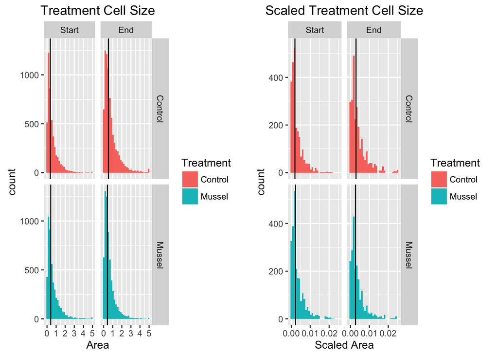

```r
# Next bin is 5, so remove 3
metrim <- metrim[-(x-3+1):-x,] # Remove 3 rows
#nrow(metrim) = 6187
x <- x-5

# Next bin is 8, so remove 5
metrim <- metrim[-(x-5+1):-x,] # Remove 5 rows
#nrow(metrim) = 6182
x <- x-8

# Next bin is 47, so remove 31.2
metrim <- metrim[-(x-31.2+1):-x,] # Remove 31.2 rows
#nrow(metrim) = 6151
x <- x-47

# Next bin is 11, so remove 7.2
metrim <- metrim[-(x-7.2+1):-x,] # Remove 7.2 rows
#nrow(metrim) = 6144
x <- x-11

# Next bin is 42, so remove 28
metrim <- metrim[-(x-28+1):-x,] # Remove 28 rows
#nrow(metrim) = 6116
x <- x-42

# Next bin is 19, so remove 13
metrim <- metrim[-(x-13+1):-x,] # Remove 13 rows
#nrow(metrim) = 6103
x <- x-19

# Next bin is 14, so remove 9
metrim <- metrim[-(x-9+1):-x,] # Remove 9 rows
#nrow(metrim) = 6094
x <- x-14

# Next bin is 24, so remove 16
metrim <- metrim[-(x-16+1):-x,] # Remove 16 rows
#nrow(metrim) = 6078
x <- x-24

# Next bin is 31, so remove 21
metrim <- metrim[-(x-21+1):-x,] # Remove 21 rows
#nrow(metrim) = 6057
x <- x-31

# Next bin is 39, so remove 26
metrim <- metrim[-(x-26+1):-x,] # Remove 26 rows
#nrow(metrim) = 6031
x <- x-39

# Next bin is 35, so remove 23
metrim <- metrim[-(x-23+1):-x,] # Remove 23 rows
#nrow(metrim) = 6008
x <- x-35

# Next bin is 46, so remove 31
metrim <- metrim[-(x-31+1):-x,] # Remove 31 rows
#nrow(metrim) = 5977
x <- x-46

# Next bin is 49, so remove 33
metrim <- metrim[-(x-33+1):-x,] # Remove 33 rows
#nrow(metrim) = 5944
x <- x-49

# Next bin is 48, so remove 32
metrim <- metrim[-(x-32+1):-x,] # Remove 32 rows
#nrow(metrim) = 5912
x <- x-48

# Next bin is 78, so remove 52
metrim <- metrim[-(x-52+1):-x,] # Remove 52 rows
#nrow(metrim) = 5860
x <- x-78

# Next bin is 82, so remove 55
metrim <- metrim[-(x-55+1):-x,] # Remove 55 rows
#nrow(metrim) = 6011
x <- x-82

# Next bin is 83, so remove 55
metrim <- metrim[-(x-55+1):-x,] # Remove 55 rows
#nrow(metrim) = 5805
x <- x-83

# Next bin is 101, so remove 67
metrim <- metrim[-(x-67+1):-x,] # Remove 67 rows
#nrow(metrim) = 5738
x <- x-101

# Next bin is 136, so remove 91
metrim <- metrim[-(x-91+1):-x,] # Remove 91 rows
#nrow(metrim) = 5647
x <- x-136

# Next bin is 166, so remove 111
metrim <- metrim[-(x-111+1):-x,] # Remove 111 rows
#nrow(metrim) = 5536
x <- x-166

# Next bin is 197, so remove 131
metrim <- metrim[-(x-131+1):-x,] # Remove 131 rows
#nrow(metrim) = 5405
x <- x-197

# Next bin is 240, so remove 160
metrim <- metrim[-(x-160+1):-x,] # Remove 160 rows
#nrow(metrim) = 5245
x <- x-240

# Next bin is 300, so remove 200
metrim <- metrim[-(x-200+1):-x,] # Remove 200 rows
#nrow(metrim) = 5045
x <- x-300

# Next bin is 391, so remove 261
metrim <- metrim[-(x-261+1):-x,] # Remove 261 rows
#nrow(metrim) = 4784
x <- x-391

# Next bin is 478, so remove 319
metrim <- metrim[-(x-319+1):-x,] # Remove 319 rows
#nrow(metrim) = 4465
x <- x-478

# Next bin is 626, so remove 417
metrim <- metrim[-(x-417+1):-x,] # Remove 417 rows
#nrow(metrim) = 4048
x <- x-626

# Next bin is 682, so remove 455
metrim <- metrim[-(x-455+1):-x,] # Remove 455 rows
#nrow(metrim) = 3593
x <- x-682

# Next bin is 720, so remove 480
metrim <- metrim[-(x-480+1):-x,] # Remove 480 rows
#nrow(metrim) = 3113
x <- x-720

# Next bin is 751, so remove 501
metrim <- metrim[-(x-501+1):-x,] # Remove 501 rows
#nrow(metrim) = 2612
x <- x-751

# Next bin is 728, so remove 485
metrim <- metrim[-(x-485+1):-x,] # Remove 485 rows
#nrow(metrim) = 2127
x <- x-728


#### Make updated fully scaled Size dataframe
new.scale <- rbind(cstrim, cetrim)
new.scale <- rbind(new.scale, mstrim)
new.scale <- rbind(new.scale, metrim)


#ggplot(data=Size, aes(x=Area, fill=Treatment)) + geom_density(alpha=0.3) + facet_grid(.~Time) + scale_x_log10()
    # Density Plot

## Scaled Experiment Histogram
#
# print("Black lines represents median of each treatment", quote=F)
# ggplot(data=new.scale, aes(x=AreaScale, fill=Treatment)) + geom_histogram() +
#   facet_grid(Treatment~Time) + ggtitle("Treatment Cell Size") +
#   geom_vline(aes(xintercept=Median), scalmedtt)





#plot_grid(skeworig, skewscale, ncol = 2, nrow = 1)
#http://www.sthda.com/english/wiki/ggplot2-easy-way-to-mix-multiple-graphs-on-the-same-page-r-software-and-data-visualization#grid.arrange-create-and-arrange-multiple-plots

#grid.arrange(skeworig, skewscale, ncol=2)


expskeworig <- ggplot(data=Size, aes(x=AreaTrans, fill=Treatment)) + geom_histogram() +
  facet_grid(Treatment~Time) + ggtitle("Treatment Cell Size") +
  geom_vline(aes(xintercept=Median), medtt) + xlab("Area")
expskewscale <- ggplot(data=new.scale, aes(x=AreaScale, fill=Treatment)) + geom_histogram() +
  facet_grid(Treatment~Time) + ggtitle("Scaled Treatment Cell Size") + xlab("Scaled Area") +
  geom_vline(aes(xintercept=Median), scalmedtt)
multiplot(expskeworig, expskewscale, cols=2)
```

```r
# explogorig <- ggplot(data=Size, aes(x=Area, fill=Treatment)) + geom_histogram() +
#   facet_grid(Treatment~Time) + scale_x_log10() + ggtitle("Treatment Cell Size (Log Scale)") +
#   geom_vline(aes(xintercept=Median), medtt) + xlab("Area")
# explogscale <- ggplot(data=new.scale, aes(x=AreaScale, fill=Treatment)) + geom_histogram() +
#   facet_grid(Treatment~Time) + scale_x_log10() + ggtitle("Scaled Treatment Cell Size (Log Scale)") +
#   geom_vline(aes(xintercept=Median), medtt) + xlab("Area")
# multiplot(explogorig, explogscale, cols=2)
```

## Levene’s Test of Equality of Variances

```r
levene.test(y=Size$Area, group=Size$Experiment)
```

```
##
##  modified robust Brown-Forsythe Levene-type test based on the
##  absolute deviations from the median
##
## data:  Size$Area
## Test Statistic = 59.251, p-value < 2.2e-16
```

```r
print("Sample variances are significantly different")
```

```
## [1] "Sample variances are significantly different"
```

```r
levene.test(y=new.scale$Area, group=new.scale$Experiment)
```

```
##
##  modified robust Brown-Forsythe Levene-type test based on the
##  absolute deviations from the median
##
## data:  new.scale$Area
## Test Statistic = 26.608, p-value < 2.2e-16
```

```r
print("Scaled sample variances are significantly different")
```

```
## [1] "Scaled sample variances are significantly different"
```

```r
levene.test(y=new.scale$AreaLog, group=new.scale$Experiment)
```

```
##
##  modified robust Brown-Forsythe Levene-type test based on the
##  absolute deviations from the median
##
## data:  new.scale$AreaLog
## Test Statistic = 2.8645, p-value = 0.03527
```

```r
print("Scaled logged sample variances are significantly different")
```

```
## [1] "Scaled logged sample variances are significantly different"
```

```r
levene.test(y=new.scale$Area, group=new.scale$Treatment)
```

```
##
##  modified robust Brown-Forsythe Levene-type test based on the
##  absolute deviations from the median
##
## data:  new.scale$Area
## Test Statistic = 17.488, p-value = 2.918e-05
```

```r
print("Scaled variances in Control and Mussel are significantly different")
```

```
## [1] "Scaled variances in Control and Mussel are significantly different"
```

```r
levene.test(y=new.scale$Area, group=new.scale$Time)
```

```
##
##  modified robust Brown-Forsythe Levene-type test based on the
##  absolute deviations from the median
##
## data:  new.scale$Area
## Test Statistic = 17.531, p-value = 2.854e-05
```

```r
print("Scaled variances in Start and End are significantly different")
```

```
## [1] "Scaled variances in Start and End are significantly different"
```

```r
# levene.test(y=new.scale$Area, group=new.scale$Experiment %in% c("Control Start", "Control End"))
# levene.test(y=new.scale$Area, group=new.scale$Experiment %in% c("Mussel Start", "Mussel End"))
# levene.test(y=new.scale$Area, group=new.scale$Experiment %in% c("Control Start", "Mussel Start"))
# levene.test(y=new.scale$Area, group=new.scale$Experiment %in% c("Control End", "Mussel End"))
# print("Scaled variances are significantly different between Control and Mussel, but not significantly different within Control and Mussel")


#sd(Size$Area[controlstart])
#sd(Size$Area[controlend])
#sd(Size$Area[musselstart])
#sd(Size$Area[musselend])

#sd(Size$AreaLog[controlstart])
#sd(Size$AreaLog[controlend])
#sd(Size$AreaLog[musselstart])
#sd(Size$AreaLog[musselend])
```

## Wilcoxon-Mann-Whitney Test

##### UNRELIABLE BECAUSE VARIANCES ARE SIGNIFICANTLY DIFFERENT

**Control Start vs. Mussel Start**

```r
wilcox.test(x=Size$Area[Size$Experiment=="Control Start"], y=Size$Area[Size$Experiment=="Mussel Start"], alternative = "less")
```

```
##
##  Wilcoxon rank sum test with continuity correction
##
## data:  Size$Area[Size$Experiment == "Control Start"] and Size$Area[Size$Experiment == "Mussel Start"]
## W = 9902100, p-value = 6.197e-10
## alternative hypothesis: true location shift is less than 0
```

```r
wilcox.test(x=new.scale$Area[new.scale$Experiment=="Control Start"],
            y=new.scale$Area[new.scale$Experiment=="Mussel Start"], alternative = "less")
```

```
##
##  Wilcoxon rank sum test with continuity correction
##
## data:  new.scale$Area[new.scale$Experiment == "Control Start"] and new.scale$Area[new.scale$Experiment == "Mussel Start"]
## W = 2464500, p-value = 7.748e-06
## alternative hypothesis: true location shift is less than 0
```

```r
print("Control Start is significantly smaller than Mussel Start", quote=F)
```

```
## [1] Control Start is significantly smaller than Mussel Start
```

**Control End vs. Mussel End**

```
##
##  Wilcoxon rank sum test with continuity correction
##
## data:  Size$AreaLog[controlend] and Size$AreaLog[musselend]
## W = 26584000, p-value < 2.2e-16
## alternative hypothesis: true location shift is greater than 0
```

```
## [1] Control End is significantly larger than Mussel End
```

**Control Start vs. Control End**

```
##
##  Wilcoxon rank sum test with continuity correction
##
## data:  Size$Area[controlstart] and Size$Area[controlend]
## W = 14259000, p-value < 2.2e-16
## alternative hypothesis: true location shift is less than 0
```

```
## [1] Control Start is significantly smaller than Control End
```

**Mussel Start vs. Mussel End**

```
##
##  Wilcoxon rank sum test with continuity correction
##
## data:  Size$AreaLog[musselstart] and Size$AreaLog[musselend]
## W = 14612000, p-value = 0.1668
## alternative hypothesis: true location shift is not equal to 0
```

```
## [1] There is no significant difference between Mussel Start & Mussel End
```

## Kruskal-Wallis Test

```r
### https://statistics.laerd.com/spss-tutorials/kruskal-wallis-h-test-using-spss-statistics.php

#kruskal.test(x=Size$Area, g=Size$Experiment)
#kruskal.test(x=Size$AreaLog, g=Size$Experiment)

#kruskal.test(x=Size$Area, g=Size$Treatment)
#kruskal.test(x=Size$AreaLog, g=Size$Treatment)

#kruskal.test(x=Size$Area, g=Size$Time)
#kruskal.test(x=Size$AreaLog, g=Size$Time)

kruskal.test(formula=Area ~ Experiment, data=Size, subset=Size$Experiment=="Control Start"|Size$Experiment=="Control End")
```

```
##
##  Kruskal-Wallis rank sum test
##
## data:  Area by Experiment
## Kruskal-Wallis chi-squared = 284.3, df = 1, p-value < 2.2e-16
```

```r
print("Control Start and Control End cell sizes are significantly different")
```

```
## [1] "Control Start and Control End cell sizes are significantly different"
```

```r
kruskal.test(formula=Area ~ Experiment, data=Size, subset=Size$Experiment=="Mussel Start"|Size$Experiment=="Mussel End")
```

```
##
##  Kruskal-Wallis rank sum test
##
## data:  Area by Experiment
## Kruskal-Wallis chi-squared = 1.9111, df = 1, p-value = 0.1668
```

```r
print("Mussel Start and Mussel End cell sizes are not significantly different")
```

```
## [1] "Mussel Start and Mussel End cell sizes are not significantly different"
```

```r
kruskal.test(formula=Area ~ Experiment, data=Size, subset=Size$Experiment=="Control Start"|Size$Experiment=="Mussel Start")
```

```
##
##  Kruskal-Wallis rank sum test
##
## data:  Area by Experiment
## Kruskal-Wallis chi-squared = 36.906, df = 1, p-value = 1.239e-09
```

```r
print("Control Start and Mussel Start cell sizes are significantly different")
```

```
## [1] "Control Start and Mussel Start cell sizes are significantly different"
```

```r
kruskal.test(formula=Area ~ Experiment, data=Size, subset=Size$Experiment=="Control End"|Size$Experiment=="Mussel End")
```

```
##
##  Kruskal-Wallis rank sum test
##
## data:  Area by Experiment
## Kruskal-Wallis chi-squared = 179.01, df = 1, p-value < 2.2e-16
```

```r
print("Control End and Mussel End cell sizes are significantly different")
```

```
## [1] "Control End and Mussel End cell sizes are significantly different"
```

## Discussion

**ImageJ Bias**  
ImageJ is unable to distinguish between single cells, paired cells, & clusters of cells. Many of the extremely large measurements are likely due to clustered cells, as well as other measurements that fall throughout the distribution. I was unable to remove these large measurements because the DAPI samples represent the 0.22 - 153 um fraction. Although the largest cell size measurement (22.6 um) was well below the 153 um threshold, there is still a possibility that these large measurements are not due to ImageJ bias.

**Cell Number**  
Cell number did not significantly change from Control Start to Control End; however, it did significantly decrease from Mussel Start to Mussel End. This change could be due to mussel predation.

**Cell Size**  
Within the Control experiments, Start was significantly smaller than End. Within the Mussel Experiments, there was no significant change in cell size. When comparing the Start of the experiments, Control was significantly smaller than Mussel. However, at the end, Control was significantly larger than Mussel. This may suggest that mussels control bacterial cell size through predation, and when bacteria are allowed to grow in the absence of these predators, they are grow to much larger sizes.